# 02 · Multilevel sPLS-DA

## Load packages

`pROC` and `fgsea` are called with `::`.

```r
pacman::p_load(here, mixOmics, dplyr, tidyr, purrr, readxl, ggplot2, patchwork, writexl)
here::i_am("07_Multivariate/02_splsda/a_script/02_splsda.qmd")
```

## Read proteins

The blood-adjusted abundances keep the blood index out of the panels.

```r
stage <- here("07_Multivariate", "02_splsda")
proteins <- readRDS(here("01_Preprocess", "02_Quantification", "c_data", "proteins_adjusted.rds"))
targets <- proteins$targets
gene_of <- set_names(proteins$genes$Genes, rownames(proteins))
dim(proteins$E)
```

```
[1] 3042  131
```

## Build the five comparisons

Sparse PLS-DA (Lê Cao et al. 2011, doi:10.1186/1471-2105-12-253) asks whether a few proteins together separate two groups. Each comparison takes two samples per participant with a one-factor multilevel design (Liquet et al. 2012), so it compares a person’s two samples; a two-factor design on all four samples is not used, because on this crossover its decomposition is computed from the class labels themselves.

```r
legs <- targets |>
  mutate(leg_id = paste(participant, leg, sep = "_")) |>
  select(leg_id, participant, treatment, timepoint, sample_id) |>
  pivot_wider(names_from = timepoint, values_from = sample_id) |>
  drop_na(T1, T2)

training <- function(arm) {
  arm_legs <- filter(legs, treatment == arm)
  list(
    x = t(proteins$E[, c(arm_legs$T1, arm_legs$T2)]),
    y = factor(rep(c("T1", "T2"), each = nrow(arm_legs))),
    participant = rep(arm_legs$participant, 2)
  )
}

paired_legs <- legs |> filter(n() == 2, .by = participant)
change <- t(proteins$E[, paired_legs$T2] - proteins$E[, paired_legs$T1])
rownames(change) <- paired_legs$leg_id
arms_at <- function(time) {
  samples <- targets |> filter(timepoint == time) |> filter(n() == 2, .by = participant)
  list(
    x = t(proteins$E[, samples$sample_id]), y = factor(samples$treatment, c("HLRT", "BFR")),
    participant = samples$participant
  )
}

comparisons <- list(
  training_bfr = training("BFR"),
  training_hlrt = training("HLRT"),
  arms_pre = arms_at("T1"),
  arms_post = arms_at("T2"),
  arms_change = list(
    x = change, y = factor(paired_legs$treatment, c("HLRT", "BFR")),
    participant = paired_legs$participant
  )
)
comparison_labels <- c(
  training_bfr = "Training, BFR leg: T1 vs T2",
  training_hlrt = "Training, HLRT leg: T1 vs T2",
  arms_pre = "BFR vs HLRT, before training",
  arms_post = "BFR vs HLRT, after training",
  arms_change = "BFR vs HLRT, training change"
)
map(comparisons, \(cmp) table(cmp$y))
```

```
$training_bfr

T1 T2
32 32

$training_hlrt

T1 T2
33 33

$arms_pre

HLRT  BFR
  33   33

$arms_post

HLRT  BFR
  32   32

$arms_change

HLRT  BFR
  32   32
```

## Tune, fit and cross-validate

Folds hold out whole participants, so the balanced error rate (BER, 0.5 is chance) and AUC are judged on people the model has not seen. Panel size is tuned on the same data and there is no permutation reference, so the error rates lean optimistic.

```r
keep_grid <- c(5, 10, 20, 50, 100, 200, 500, 1000)
fit_splsda <- function(cmp) {
  tuned <- tune.splsda(
    cmp$x, cmp$y, ncomp = 2, test.keepX = keep_grid, multilevel = cmp$participant,
    validation = "Mfold", folds = 5, nrepeat = 50, dist = "max.dist", measure = "BER",
    seed = 2026
  )
  model <- splsda(cmp$x, cmp$y, ncomp = 2, keepX = tuned$choice.keepX,
    multilevel = cmp$participant)
  performance <- perf(model, validation = "Mfold", folds = 5, nrepeat = 50, dist = "all",
    auc = TRUE, seed = 2026)
  list(tuned = tuned, model = model, performance = performance)
}
fits <- map(comparisons, fit_splsda)
```

## Error and AUC

BER under each of the package’s three distances shows whether a call depends on the rule.

```r
model_summary <- imap(fits, function(fit, name) {
  ber <- fit$performance$error.rate$BER
  ber_sd <- fit$performance$error.rate.sd$BER
  tibble(
    comparison = name,
    n_participants = n_distinct(comparisons[[name]]$participant),
    n_samples = nrow(comparisons[[name]]$x),
    component = 1:2,
    keep_x = unname(fit$tuned$choice.keepX),
    tune_ber = map2_dbl(keep_x, component, \(k, h) fit$tuned$error.rate[as.character(k), h]),
    ber_max = ber[, "max.dist"],
    ber_max_sd = ber_sd[, "max.dist"],
    ber_centroids = ber[, "centroids.dist"],
    ber_mahalanobis = ber[, "mahalanobis.dist"],
    auc = map_dbl(fit$performance$auc, "AUC.mean"),
    auc_sd = map_dbl(fit$performance$auc, "AUC.sd")
  )
}) |>
  list_rbind()
model_summary |> mutate(across(where(is.double), \(x) round(x, 3)))
```

```
# A tibble: 10 × 12
   comparison    n_participants n_samples component keep_x tune_ber ber_max
   <chr>                  <int>     <int>     <int>  <dbl>    <dbl>   <dbl>
 1 training_bfr              32        64         1   1000    0.176   0.176
 2 training_bfr              32        64         2    200    0.169   0.174
 3 training_hlrt             33        66         1     20    0.006   0.006
 4 training_hlrt             33        66         2   1000    0.002   0.003
 5 arms_pre                  33        66         1      5    0.394   0.394
 6 arms_pre                  33        66         2   1000    0.396   0.421
 7 arms_post                 32        64         1    500    0.444   0.444
 8 arms_post                 32        64         2     10    0.427   0.412
 9 arms_change               32        64         1     50    0.459   0.459
10 arms_change               32        64         2     20    0.432   0.419
# ℹ 5 more variables: ber_max_sd <dbl>, ber_centroids <dbl>,
#   ber_mahalanobis <dbl>, auc <dbl>, auc_sd <dbl>
```

## Panels

Stability, the share of the 250 refits that also selected a protein, separates a reproducible panel from one fitted to noise.

```r
panels <- imap(fits, function(fit, name) {
  map(1:2, function(h) {
    loading <- fit$model$loadings$X[, h]
    stable <- fit$performance$features$stable[[h]]
    tibble(protein = names(loading), loading = unname(loading)) |>
      filter(loading != 0) |>
      mutate(
        comparison = name, component = h, gene = gene_of[protein],
        stability = coalesce(as.numeric(stable[protein]), 0), .before = protein
      ) |>
      arrange(desc(abs(loading)))
  }) |>
    list_rbind()
}) |>
  list_rbind()
panels |> summarise(proteins = n(), stable_80 = sum(stability >= 0.8),
  .by = c(comparison, component))
```

```
# A tibble: 10 × 4
   comparison    component proteins stable_80
   <chr>             <int>    <int>     <int>
 1 training_bfr          1     1000       563
 2 training_bfr          2      200        44
 3 training_hlrt         1       20        12
 4 training_hlrt         2     1000       309
 5 arms_pre              1        5         1
 6 arms_pre              2     1000        67
 7 arms_post             1      500       166
 8 arms_post             2       10         0
 9 arms_change           1       50        10
10 arms_change           2       20         0
```

## Transfer between arms

Scoring one arm’s legs with the other arm’s training panel asks whether the signature is shared. The scored legs belong to the participants the model was fitted on, so the transfer AUC is not comparable with the cross-validated AUC.

```r
transfer <- tibble(model_arm = c("HLRT", "BFR"), scored_arm = c("BFR", "HLRT")) |>
  mutate(
    transfer_auc = map2_dbl(model_arm, scored_arm, function(model_arm, scored_arm) {
      target <- comparisons[[paste0("training_", tolower(scored_arm))]]
      model <- fits[[paste0("training_", tolower(model_arm))]]$model
      score <- predict(model, target$x, multilevel = target$participant)$predict[, "T2", 1]
      as.numeric(pROC::auc(pROC::roc(target$y, score, levels = c("T1", "T2"), direction = "<",
        quiet = TRUE)))
    }),
    own_cv_auc = map_dbl(scored_arm, function(arm) {
      filter(model_summary, comparison == paste0("training_", tolower(arm)), component == 1)$auc
    })
  )
transfer
```

```
# A tibble: 2 × 4
  model_arm scored_arm transfer_auc own_cv_auc
  <chr>     <chr>             <dbl>      <dbl>
1 HLRT      BFR               0.912      0.879
2 BFR       HLRT              0.981      1.000
```

## Annotate the training panels

Modules and over-represented sets say what the training panels are made of. The arm panels predict at chance, so annotating them would describe noise.

```r
network_book <- here("04_Network", "01_modules", "c_data", "01_modules.xlsx")
module_of <- read_excel(network_book, "membership") |>
  filter(network == "main") |>
  select(protein, module) |>
  left_join(
    read_excel(network_book, "modules") |> filter(network == "main") |> select(module, top_set),
    by = "module"
  )
panels <- left_join(panels, module_of, by = "protein")
sets <- readRDS(here("03_Pathway_Enrichment", "00_build_gene_sets", "c_data", "gene_sets.rds"))
universe <- unique(na.omit(proteins$genes$Genes))
panel_pathways <- panels |>
  filter(startsWith(comparison, "training"), component == 1) |>
  summarise(genes = list(unique(na.omit(gene))), .by = comparison) |>
  mutate(result = map(genes, function(genes) {
    as_tibble(fgsea::fora(sets, genes, universe = universe, minSize = 15, maxSize = 500))
  })) |>
  select(comparison, result) |>
  unnest(result) |>
  filter(pval < 0.05) |>
  mutate(overlapGenes = map_chr(overlapGenes, paste, collapse = ";")) |>
  arrange(comparison, pval)
panels |>
  filter(startsWith(comparison, "training"), component == 1, module != "M0") |>
  count(comparison, module, top_set, sort = TRUE) |>
  slice_max(n, n = 5, by = comparison)
```

```
# A tibble: 8 × 4
  comparison    module top_set                                           n
  <chr>         <chr>  <chr>                                         <int>
1 training_bfr  M3     Hallmark|HALLMARK_OXIDATIVE_PHOSPHORYLATION     227
2 training_bfr  M1     GOBP|GOBP_MUSCLE_CELL_DIFFERENTIATION           128
3 training_bfr  M4     GOBP|GOBP_CALCIUM_ION_TRANSMEMBRANE_TRANSPORT   108
4 training_bfr  M2     GO_Slim|CYTOSKELETON_ORGANIZATION                77
5 training_bfr  M5     Hallmark|HALLMARK_HEME_METABOLISM                39
6 training_hlrt M3     Hallmark|HALLMARK_OXIDATIVE_PHOSPHORYLATION       8
7 training_hlrt M4     GOBP|GOBP_CALCIUM_ION_TRANSMEMBRANE_TRANSPORT     8
8 training_hlrt M2     GO_Slim|CYTOSKELETON_ORGANIZATION                 3
```

```r
slice_min(panel_pathways, pval, n = 5, by = comparison) |>
  select(comparison, pathway, overlap, size, padj)
```

```
# A tibble: 10 × 5
   comparison    pathway                                   overlap  size    padj
   <chr>         <chr>                                       <int> <int>   <dbl>
 1 training_bfr  Hallmark|HALLMARK_OXIDATIVE_PHOSPHORYLAT…      93   174 1.36e-5
 2 training_bfr  Reactome|REACTOME_MITOCHONDRIAL_PROTEIN_…      52    85 5.49e-5
 3 training_bfr  GOBP|GOBP_TRICARBOXYLIC_ACID_CYCLE             23    28 6.73e-5
 4 training_bfr  Reactome|REACTOME_AEROBIC_RESPIRATION_AN…      94   187 1.45e-4
 5 training_bfr  GOBP|GOBP_CELLULAR_RESPIRATION                 99   201 1.93e-4
 6 training_hlrt KEGG_Legacy|KEGG_ARGININE_AND_PROLINE_ME…       4    29 5.80e-2
 7 training_hlrt KEGG_Legacy|KEGG_PROPANOATE_METABOLISM          3    26 5.72e-1
 8 training_hlrt KEGG_Legacy|KEGG_VALINE_LEUCINE_AND_ISOL…       3    37 8.39e-1
 9 training_hlrt GOBP|GOBP_L_AMINO_ACID_CATABOLIC_PROCESS        3    39 8.39e-1
10 training_hlrt GOBP|GOBP_SMALL_MOLECULE_CATABOLIC_PROCE…       5   157 8.39e-1
```

## Figures

One page per comparison; the ROC curve of every repeat shows how much the AUC moves with the folds.

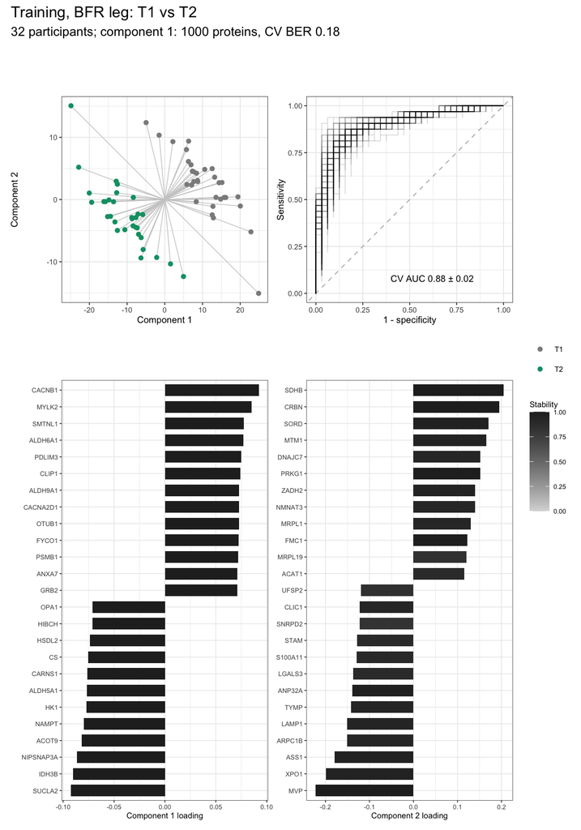

```r
group_colours <- c(T1 = "grey55", T2 = "#009E73", HLRT = "#0072B2", BFR = "#D55E00")

score_plot <- function(fit, cmp) {
  as_tibble(fit$model$variates$X, rownames = "sample") |>
    mutate(group = cmp$y, participant = cmp$participant) |>
    ggplot(aes(comp1, comp2, colour = group)) +
    geom_line(aes(group = participant), colour = "grey80", linewidth = 0.3) +
    geom_point(size = 1.6) +
    scale_colour_manual(values = group_colours) +
    labs(x = "Component 1", y = "Component 2", colour = NULL) +
    theme_bw(base_size = 8)
}

roc_plot <- function(fit, cmp) {
  predicted <- fit$performance$predict$comp1
  curves <- map(seq_len(dim(predicted)[3]), function(r) {
    roc <- pROC::roc(cmp$y, predicted[, 2, r], levels = levels(cmp$y), direction = "<",
      quiet = TRUE)
    tibble(repeat_id = r, specificity = roc$specificities, sensitivity = roc$sensitivities)
  }) |>
    list_rbind()
  auc <- fit$performance$auc$comp1
  ggplot(curves, aes(1 - specificity, sensitivity, group = repeat_id)) +
    geom_abline(linetype = "dashed", colour = "grey70") +
    geom_step(alpha = 0.15, direction = "vh") +
    annotate("text", x = 0.62, y = 0.08, size = 2.8,
      label = sprintf("CV AUC %.2f ± %.2f", auc[["AUC.mean"]], auc[["AUC.sd"]])) +
    coord_equal() +
    labs(x = "1 - specificity", y = "Sensitivity") +
    theme_bw(base_size = 8)
}

loading_plot <- function(name, h) {
  panels |>
    filter(comparison == name, component == h) |>
    slice_max(abs(loading), n = 25, with_ties = FALSE) |>
    ggplot(aes(loading, reorder(gene, loading), fill = stability)) +
    geom_col(width = 0.7) +
    scale_fill_gradient(low = "grey85", high = "grey15", limits = c(0, 1)) +
    labs(x = paste("Component", h, "loading"), y = NULL, fill = "Stability") +
    theme_bw(base_size = 7)
}

pages <- imap(fits, function(fit, name) {
  headline <- filter(model_summary, comparison == name, component == 1)
  (score_plot(fit, comparisons[[name]]) | roc_plot(fit, comparisons[[name]])) /
    (loading_plot(name, 1) | loading_plot(name, 2)) +
    plot_layout(heights = c(1, 1.4), guides = "collect") +
    plot_annotation(
      title = comparison_labels[[name]],
      subtitle = sprintf("%d participants; component 1: %d proteins, CV BER %.2f",
        headline$n_participants, headline$keep_x, headline$ber_max)
    )
})
pages[[1]]
```

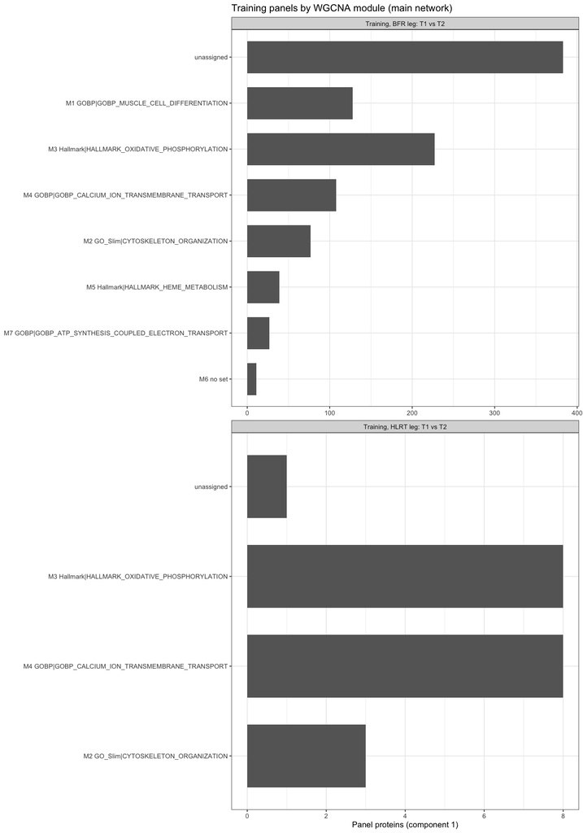

```r
module_page <- panels |>
  filter(startsWith(comparison, "training"), component == 1) |>
  mutate(
    module = if_else(module == "M0", "unassigned", paste(module, coalesce(top_set, "no set"))),
    comparison = comparison_labels[comparison]
  ) |>
  count(comparison, module) |>
  slice_max(n, n = 10, by = comparison, with_ties = FALSE) |>
  ggplot(aes(n, reorder(module, n))) +
  geom_col(width = 0.7, fill = "grey40") +
  facet_wrap(~comparison, scales = "free", ncol = 1) +
  labs(x = "Panel proteins (component 1)", y = NULL,
    title = "Training panels by WGCNA module (main network)") +
  theme_bw(base_size = 7)
module_page
```

```r
pdf(file.path(stage, "b_reports", "02_splsda.pdf"), width = 8.27, height = 11.69)
walk(pages, print)
print(module_page)
invisible(dev.off())
```

## Save results

```r
write_xlsx(
  list(
    models = model_summary,
    panels = panels,
    transfer = transfer,
    panel_pathways = panel_pathways,
    scores = imap(fits, function(fit, name) {
      as_tibble(fit$model$variates$X, rownames = "sample") |>
        mutate(comparison = name, participant = comparisons[[name]]$participant,
          group = as.character(comparisons[[name]]$y), .before = 1)
    }) |>
      list_rbind()
  ),
  file.path(stage, "c_data", "02_splsda.xlsx")
)
```